# Fall 2020 - Math 421 - Midterm

# Instruction

The midterm has two components: the Rmarkdown notebook (html) and the presentation. The notebook and the presentation file are due Nov 26. We will do the presentation in class

**The notebook:** The notebook should be created using `rmarkdown` (like other assignments). The notebook should have a title.

**The Presentation:** Present your results in 5-10 minutes. To make the presentation using Rmarkdown, do the follows:

```
- In Rstudio -> File -> New File -> R markdown

- In the left panel, click to Presentation -> Click OK

- Now you have an Rmarkdown that can be knitted to be a html presentation
```

**What to present**:

- Present Part 2 - Visualization
- Present Question Question 4, 5 and 6 in Part 3.
- Present any errors/challenges you run into and how you fix/overcome them.

**Data:**

The data for the mid-term project is the Rhode Island Department of Health Hospital Discharge Data. Each row of the data presents a patient.

Link: https://drive.google.com/open?id=15QNBf6YYKocK2nNIfpKDer58kQnCPNZJ

## I. Data Wranggling

1. Download the data file `hdd0318cy.sas7bdat`.
2. Use `read_sas` in library `haven` to read the data.

```r
library(haven)
library(haven)
dfmt1 <- read_sas('hdd0318cy.sas7bdat')
```

3. Filter the data to have only patients of the year 2018 (`yod==2018`)

```r
library(tidyverse)
mt <- filter(dfmt1, dfmt1$yod==18)
```

4. Select to work with only following variables:

```r
                      # "yod, payfix,pay_ub92,age,
                      "sex,raceethn,provider,moa,
                      yoa,mod,admtype, asource,
                      preopday,los, service, icu,ccu,
                      dispub92,payer,drg,trandb,
                      randbg,randbs,orr, anes,seq,
                      lab,dtest, ther,blood,phar,
                      other,patcon,bwght,total,tot,
                      ecodub92,b_wt,pt_state,diag_adm,ancilar,
                      campus,er_fee,er_chrg,er_mode,obs_chrg,
                      obs_hour,psycchrg,nicu_day" #
```

```
## [1] "sex,raceethn,provider,moa, \n                      yoa,mod,admtype, asource, \n                      preopday,los, service, icu,ccu,    \n                      dispub92,payer,drg,trandb, \n                      randbg,randbs,orr, anes,seq,   \n                      lab,dtest, ther,blood,phar…
```

```r
library(dplyr)
midterm2 <- select(mt,yod,payfix,pay_ub92,age,sex,raceethn,provider,moa,yoa,mod,admtype, asource,preopday,los,service,icu,ccu,dispub92,payer  ,drg,trandb,randbg,randbs,orr,anes,seq, lab,dtest, ther,blood,phar,other,patcon,bwght,total,tot,ecodub92,b_wt,pt_state,diag_adm,ancilar, campus,er_fee,er_chrg,er_mode,obs_chrg,obs_hour,psycchrg,nicu_day)
```

*Notice*: You may want to save the current data to your computer for easy access later. To save the data file use `write_csv(df, 'midterm.csv')`, for example.

```r
write_csv(midterm2, 'midterm.csv')
```

5. What are variables that have missing values?

```r
colSums(is.na(midterm2))
```

```
##      yod   payfix pay_ub92      age      sex raceethn provider      moa
##        0   131478        0        0        0        0        0        0
##      yoa      mod  admtype  asource preopday      los  service      icu
##        0        0        0        0    60486        0        0        0
##      ccu dispub92    payer      drg   trandb   randbg   randbs      orr
##        0        0        0        0        0        0        0        0
##     anes      seq      lab    dtest     ther    blood     phar    other
##        0        0        0        0        0        0        0        0
##   patcon    bwght    total      tot ecodub92     b_wt pt_state diag_adm
##        0        0        0        0        0        0        0        0
##  ancilar   campus   er_fee  er_chrg  er_mode obs_chrg obs_hour psycchrg
##        0        0        0        0        0        0    77343        0
## nicu_day
##   124090
```

```r
# Variables with missing values include: payfix, preopday, obs_hour, nicu_day #
```

6. Remove all variables with missing values

```r
midterm2$payfix <- NULL
midterm2$preopday <- NULL
midterm2$obs_hour <- NULL
midterm2$nicu_day <- NULL
```

7. Refer to the data description in the file `HDD2015-18cy6-20-19.docx`, which variable recording the month of admission?, which variable recording the month of discharge?

```r
#MOA = Month of Admission #
#MOD = Month of Discharge #
```

8. Which month admitted the most number of patients? Which month admitted the most number of male patients?

```r
table(midterm2$moa)
```

```
##
##     1     2     3     4     5     6     7     8     9    10    11    12
## 11309 10259 11073 11174 11404 10690 10962 11199 10666 11408 10636 10698
```

```r
# Highest number of patients in October #
```

```r
dfmale <- filter(midterm2, sex == "1")
```

```r
table(dfmale$moa)
```

```
##
##    1    2    3    4    5    6    7    8    9   10   11   12
## 4970 4546 4978 4989 5066 4810 4910 5028 4683 5164 4800 4855
```

```r
#Highest number of male patients admitted in October #
```

9. Which month has the most number of teenage female patients?

```r
#Create Female Table #
dffemale <- filter(midterm2, sex == "2")
```

```r
#Filter for age between 13 and 19
teenagefemale <- filter(dffemale, age <=19 & age >12)
```

```r
table(teenagefemale$moa)
```

```
##
##   1   2   3   4   5   6   7   8   9  10  11  12
## 207 172 226 187 220 169 171 172 196 212 177 208
```

```r
# March has greatest number of teenage female patients #
```

10. Which provider has the most number of female patients in October?

```r
#Filter for Month of October #
femaleoct <- filter(dffemale, moa == "10")
```

```r
table(femaleoct$provider)
```

```
##
## 7201 7202 7204 7205 7206 7209 7210 7211 7213 7214 7215 7216
##  294  212  872 1517  333  351  699  122  317 1224   46  256
```

```r
# Provider 7205(Rhode Island Hosptial) has the most female patients in October, with 1517 total. #
```

11. Is female patients older than male patients, on average?

```r
midterm2 %>%
group_by(sex) %>%
summarize(meanage = mean(age))
```

```
## # A tibble: 3 x 2
##   sex   meanage
##   <chr>   <dbl>
## 1 1        51.5
## 2 2        50.9
## 3 9        43
```

```r
# On Average, males are older by 0.635 years. #
```

12. Calculate the average age of patients by months. Which month has the oldest patients on average age?

```r
midterm2 %>%
group_by(moa) %>%
summarize(meanage = mean(age))
```

```
## # A tibble: 12 x 2
##      moa meanage
##    <dbl>   <dbl>
##  1     1    51.8
##  2     2    51.2
##  3     3    51.1
##  4     4    51.4
##  5     5    50.6
##  6     6    51.5
##  7     7    51.3
##  8     8    50.9
##  9     9    50.6
## 10    10    50.8
## 11    11    51.0
## 12    12    51.5
```

```r
# January has the highest average age for patients at 51.79 years old. #
```

13. What is the name of the provider that has the highest total charge?

```r
midterm2 %>%
group_by(provider) %>%
summarize(totalcharge = (sum(tot)))
```

```
## # A tibble: 12 x 2
##    provider totalcharge
##    <chr>          <dbl>
##  1 7201       126539717
##  2 7202       187925007
##  3 7204       678940049
##  4 7205      1788373499
##  5 7206       212906243
##  6 7209       163943679
##  7 7210       427464111
##  8 7211        64990985
##  9 7213       240776070
## 10 7214       428480981
## 11 7215        77010051
## 12 7216       114603878
```

```r
# Provider 7205(Rhode Island Hospital) has the highest total charge.#
```

14. What is the name of the provider that has the least total charge for teenage male on average?

```r
#Filter male table for teenage ages #
teenagemale<- filter(dfmale, age <=19 & age >12)
```

```r
teenagemale %>%
group_by(provider) %>%
summarize(avgcharge = mean(tot))
```

```
## # A tibble: 12 x 2
##    provider avgcharge
##    <chr>        <dbl>
##  1 7201        14434.
##  2 7202        29389.
##  3 7204        24989.
##  4 7205        40215.
##  5 7206        10360.
##  6 7209        26573.
##  7 7210        18586.
##  8 7211        19742.
##  9 7213        22618.
## 10 7214        28950
## 11 7215       100440.
## 12 7216        24060.
```

```r
# Provider 7206(Roger Williams) has least average charge for teenage males. #
```

15. Calculate the length of stays by races. Which race has the longest length of stays on average?

```r
midterm2 %>%
group_by(raceethn) %>%
summarize(avgstay = mean(los))
```

```
## # A tibble: 8 x 2
##   raceethn avgstay
##   <chr>      <dbl>
## 1 ""          4.38
## 2 "1"         4.93
## 3 "2"         5.28
## 4 "3"         4.41
## 5 "4"         5.54
## 6 "6"         5.35
## 7 "7"         4.67
## 8 "9"         6.18
```

```r
#Race 9(Unknown Race) has the longest stay on average #
```

16. On average, how much a 20 year-old male white get charged for staying 1 day?

```r
#Filter for twenty year old white males who stayed one day #
twentywmale <- filter(dfmale, age==20, raceethn == "1", los == 1)
```

```r
twentywmale %>%
group_by(los) %>%
summarize(avgcharg = mean(tot))
```

```
## # A tibble: 1 x 2
##     los avgcharg
##   <dbl>    <dbl>
## 1     1   15320.
```

```r
# Average charge of $15,319.56 for twenty year old white males who stayed one night. #
```

## II. Data Visualization

Continue with the data from part I.

1. Provides at least 10 meaningful plots. Comments on the plots. All plots should have title, caption, appropriate labels on x and y-axis

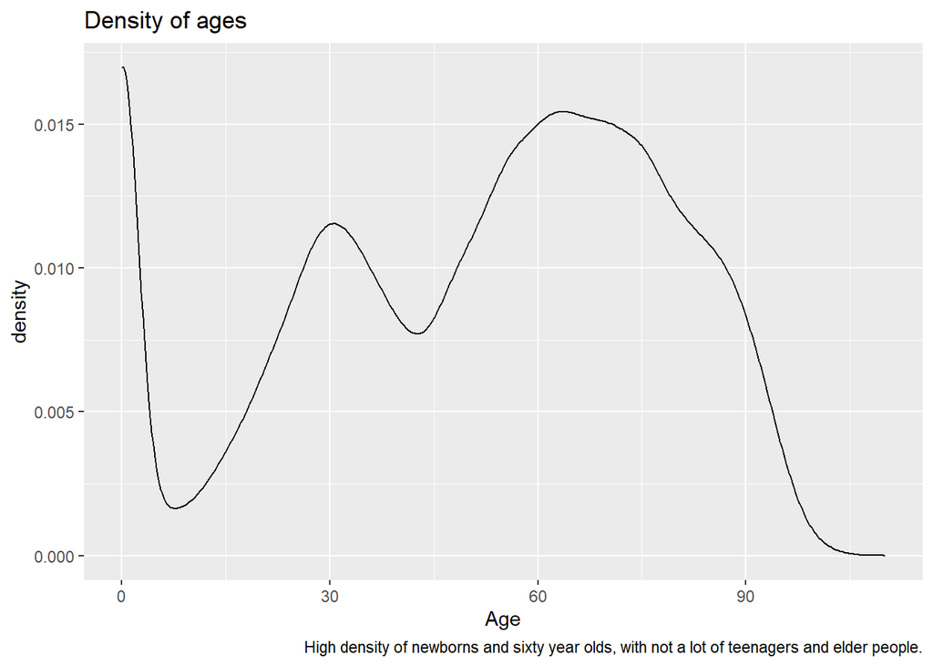

```r
# PLOT 1 #
library(ggplot2)
ggplot(midterm2, aes(x = age)) + geom_density() + labs(x = 'Age', title = 'Density of ages', caption = 'High density of newborns and sixty year olds, with not a lot of teenagers and elder people.')
```

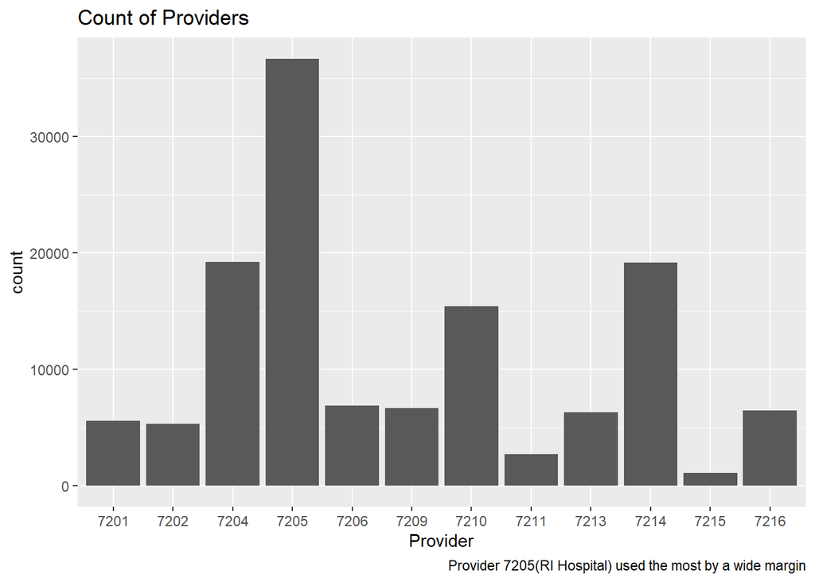

```r
# PLOT 2 #
ggplot(midterm2, aes(x = provider)) + geom_bar() + labs(x = 'Provider', title = 'Count of Providers', caption = 'Provider 7205(RI Hospital) used the most by a wide margin')
```

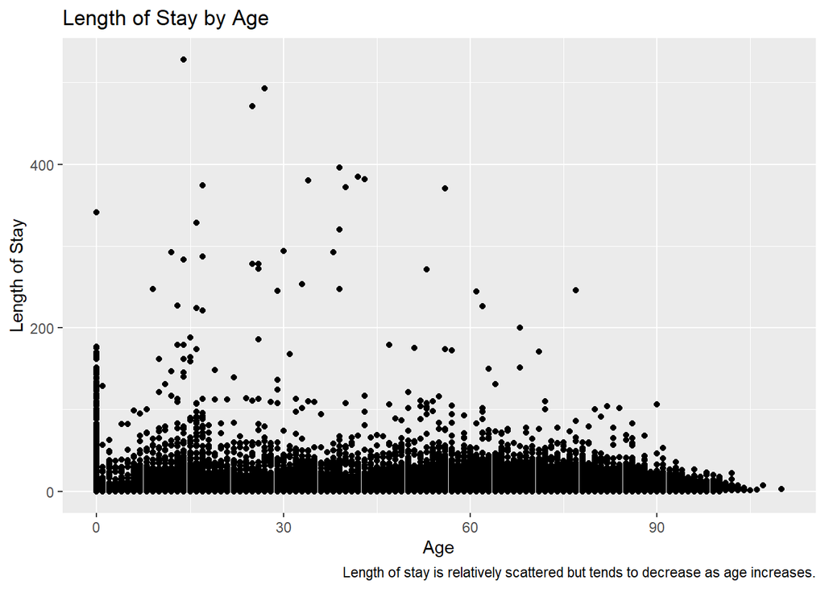

```r
#PLOT 3#
ggplot(midterm2, aes(x = age, y = los)) + geom_point() + labs(x = 'Age', y = 'Length of Stay', title = 'Length of Stay by Age', caption = 'Length of stay is relatively scattered but tends to decrease as age increases.')
```

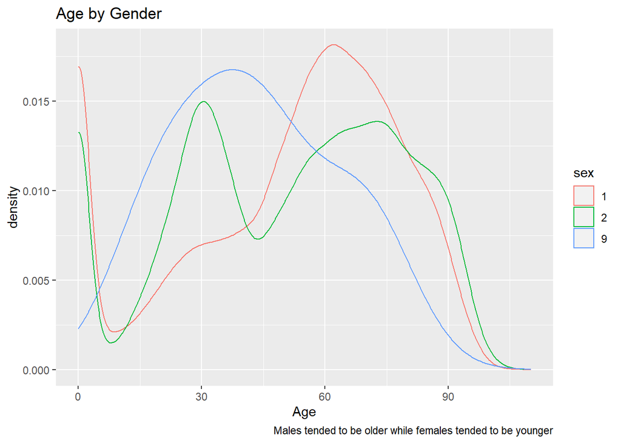

```r
#PLOT 4#
ggplot(midterm2, aes(x = age, color = sex)) + geom_density() + labs(x = 'Age', title = 'Age by Gender', caption = 'Males tended to be older while females tended to be younger')
```

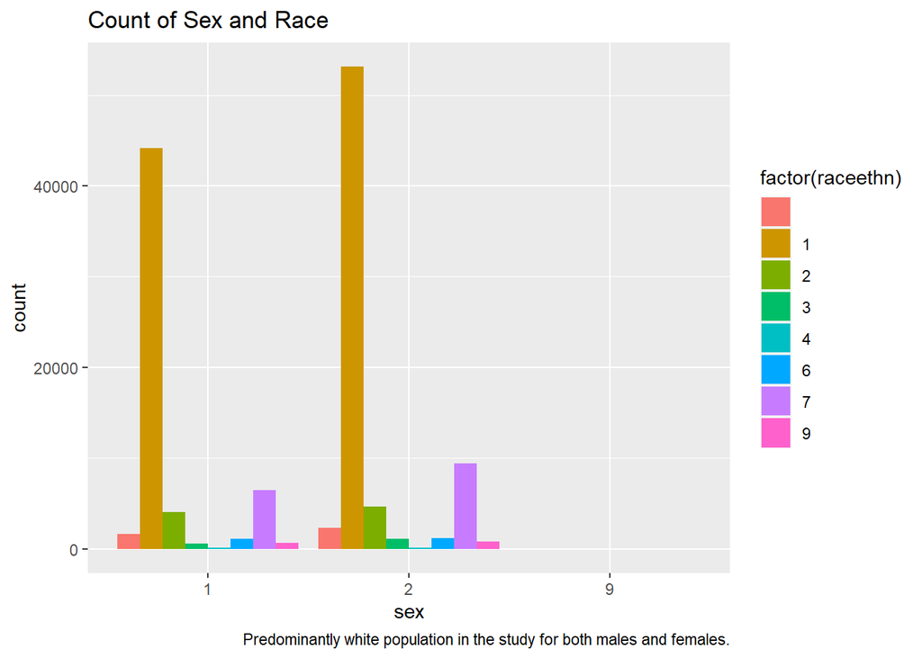

```r
#PLOT 5#
ggplot(midterm2, aes(x = sex, fill = factor(raceethn))) + geom_bar(position = 'dodge') + labs(x = 'sex', title = 'Count of Sex and Race', caption = 'Predominantly white population in the study for both males and females.')
```

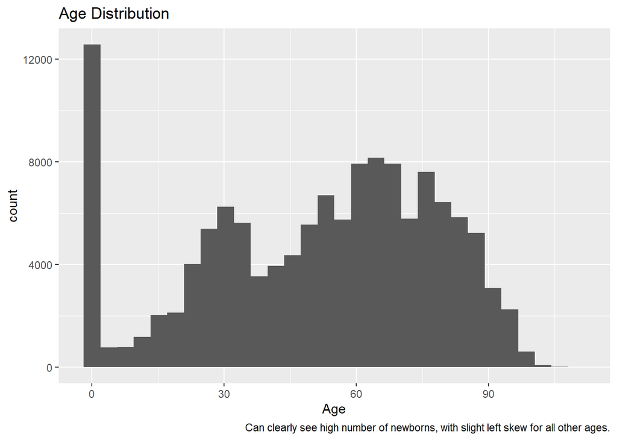

```r
#PLOT 6#
ggplot(midterm2, aes(x = age)) + geom_histogram() + labs(x = 'Age', title = 'Age Distribution', caption = 'Can clearly see high number of newborns, with slight left skew for all other ages.')
```

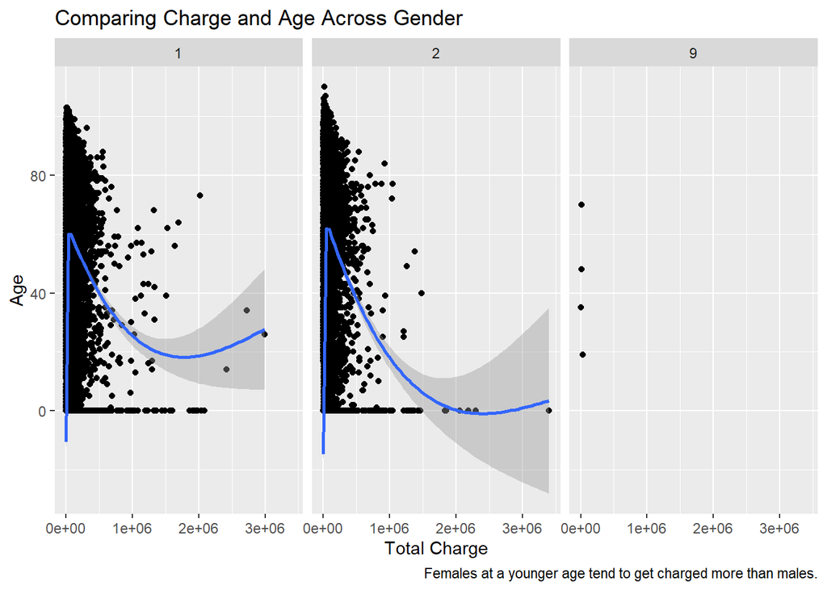

```r
#PLOT 7#
ggplot(midterm2, aes(x = tot, y = age)) + geom_point() + geom_smooth() + facet_wrap(~sex) + labs(x = 'Total Charge', y = 'Age', title = 'Comparing Charge and Age Across Gender', caption = 'Females at a younger age tend to get charged more than males.')
```